# Read Json

# Read in json files

Andreas würde gerne folgende json daten einlese Luftdaten Info Feinstaubsensoren OK Lab http://api.luftdaten.info/static/v1/data.json

according to hadley use jsonlite to read in json data

```r
library(jsonlite)
library(tidyverse)
library(rvest)
```

use rvest from hadley to web scrap data

```r
library(rvest)
Sensorenwerte <- read_html("http://api.luftdaten.info/static/v1/data.json")
class(Sensorenwerte)
```

```
[1] "xml_document" "xml_node"
```

hmm, got an xml doc, not what i was looking for…

according to hadley use jsonlite to read in json data from file or the web

```r
Sensorenwerte <- fromJSON("http://api.luftdaten.info/static/v1/data.json", flatten = TRUE)
class(Sensorenwerte)
```

```
[1] "data.frame"
```

got a data.frame, that is promissing  
lets see what is inside

```r
names(Sensorenwerte)
```

```
 [1] "id"                              "sampling_rate"
 [3] "timestamp"                       "sensordatavalues"
 [5] "location.id"                     "location.latitude"
 [7] "location.longitude"              "location.country"
 [9] "sensor.id"                       "sensor.pin"
[11] "sensor.sensor_type.id"           "sensor.sensor_type.name"
[13] "sensor.sensor_type.manufacturer"
```

```r
str(Sensorenwerte)
```

```
'data.frame':   4841 obs. of  13 variables:
 $ id                             : int  67599252 67599253 67599254 67599255 67599256 67599257 67599240 67599241 67599242 67599243 ...
 $ sampling_rate                  : logi  NA NA NA NA NA NA ...
 $ timestamp                      : chr  "2017-04-05T19:06:01" "2017-04-05T19:06:01" "2017-04-05T19:06:01" "2017-04-05T19:06:01" ...
 $ sensordatavalues               :List of 4841
  ..$ :'data.frame':    2 obs. of  3 variables:
  .. ..$ id        : int  186602761 186602760
  .. ..$ value     : chr  "81.60" "9.30"
  .. ..$ value_type: chr  "humidity" "temperature"
  ..$ :'data.frame':    2 obs. of  3 variables:
  .. ..$ id        : int  186602762 186602763
  .. ..$ value     : chr  "56.34" "39.53"
  .. ..$ value_type: chr  "P1" "P2"
  ..$ :'data.frame':    2 obs. of  3 variables:
  .. ..$ id        : int  186602765 186602764
  .. ..$ value     : chr  "48.50" "14.40"
  .. ..$ value_type: chr  "humidity" "temperature"
  ..$ :'data.frame':    2 obs. of  3 variables:
  .. ..$ id        : int  186602767 186602766
  .. ..$ value     : chr  "35.30" "16.70"
  .. ..$ value_type: chr  "humidity" "temperature"
  ..$ :'data.frame':    2 obs. of  3 variables:
  .. ..$ id        : int  186602768 186602769
  .. ..$ value     : chr  "16.73" "13.73"
  .. ..$ value_type: chr  "P1" "P2"
  ..$ :'data.frame':    2 obs. of  3 variables:
  .. ..$ id        : int  186602772 186602773
  .. ..$ value     : chr  "8.40" "7.08"
  .. ..$ value_type: chr  "P1" "P2"
  ..$ :'data.frame':    2 obs. of  3 variables:
  .. ..$ id        : int  186602734 186602733
  .. ..$ value     : chr  "37.00" "13.30"
  .. ..$ value_type: chr  "humidity" "temperature"
  ..$ :'data.frame':    2 obs. of  3 variables:
  .. ..$ id        : int  186602735 186602736
  .. ..$ value     : chr  "33.05" "15.30"
  .. ..$ value_type: chr  "P1" "P2"
  ..$ :'data.frame':    2 obs. of  3 variables:
  .. ..$ id        : int  186602737 186602738
  .. ..$ value     : chr  "39.25" "16.40"
```

[output cut: 356 more lines]

```
  .. ..$ value_type: chr  "humidity" "temperature"
  ..$ :'data.frame':    2 obs. of  3 variables:
  .. ..$ id        : int  186602587 186602586
  .. ..$ value     : chr  "50.10" "10.90"
  .. ..$ value_type: chr  "humidity" "temperature"
  .. [list output truncated]
 $ location.id                    : int  631 141 273 639 718 240 269 63 383 542 ...
 $ location.latitude              : chr  "51.025" "49.097" "47.386" "48.468" ...
 $ location.longitude             : chr  "13.826" "9.274" "8.540" "7.958" ...
 $ location.country               : chr  "DE" "DE" "CH" "DE" ...
 $ sensor.id                      : int  1277 311 575 1293 1448 507 569 466 801 1111 ...
 $ sensor.pin                     : chr  "7" "1" "7" "7" ...
 $ sensor.sensor_type.id          : int  9 14 9 9 14 14 9 14 14 9 ...
 $ sensor.sensor_type.name        : chr  "DHT22" "SDS011" "DHT22" "DHT22" ...
 $ sensor.sensor_type.manufacturer: chr  "various" "Nova Fitness" "various" "various" ...
```

the file is somewhat nested, so unnest it

```r
Sensorenwerte %>% unnest(.sep = "_") -> Sensorwerte_unnest
Sensorwerte_unnest %>% select(timestamp)
```

| timestamp |
| --- |
| 2017-04-05T19:06:01 |
| 2017-04-05T19:06:01 |
| 2017-04-05T19:06:01 |
| 2017-04-05T19:06:01 |
| 2017-04-05T19:06:01 |
| 2017-04-05T19:06:01 |
| 2017-04-05T19:06:01 |
| 2017-04-05T19:06:01 |
| 2017-04-05T19:06:01 |
| 2017-04-05T19:06:01 |

[output cut: 990 more lines]

```r
str(Sensorwerte_unnest)
```

```
'data.frame':   10173 obs. of  15 variables:
 $ id                             : int  67599252 67599252 67599253 67599253 67599254 67599254 67599255 67599255 67599256 67599256 ...
 $ sampling_rate                  : logi  NA NA NA NA NA NA ...
 $ timestamp                      : chr  "2017-04-05T19:06:01" "2017-04-05T19:06:01" "2017-04-05T19:06:01" "2017-04-05T19:06:01" ...
 $ location.id                    : int  631 631 141 141 273 273 639 639 718 718 ...
 $ location.latitude              : chr  "51.025" "51.025" "49.097" "49.097" ...
 $ location.longitude             : chr  "13.826" "13.826" "9.274" "9.274" ...
 $ location.country               : chr  "DE" "DE" "DE" "DE" ...
 $ sensor.id                      : int  1277 1277 311 311 575 575 1293 1293 1448 1448 ...
 $ sensor.pin                     : chr  "7" "7" "1" "1" ...
 $ sensor.sensor_type.id          : int  9 9 14 14 9 9 9 9 14 14 ...
 $ sensor.sensor_type.name        : chr  "DHT22" "DHT22" "SDS011" "SDS011" ...
 $ sensor.sensor_type.manufacturer: chr  "various" "various" "Nova Fitness" "Nova Fitness" ...
 $ sensordatavalues_id            : int  186602761 186602760 186602762 186602763 186602765 186602764 186602767 186602766 186602768 186602769 ...
 $ sensordatavalues_value         : chr  "81.60" "9.30" "56.34" "39.53" ...
 $ sensordatavalues_value_type    : chr  "humidity" "temperature" "P1" "P2" ...
```

set date format for time stamp

```r
library(lubridate)
Sensorwerte_unnest %>% mutate(timestamp = as.Date(timestamp)) -> Sensorwerte_unnest
str(Sensorwerte_unnest)
```

```
'data.frame':   10173 obs. of  15 variables:
 $ id                             : int  67599252 67599252 67599253 67599253 67599254 67599254 67599255 67599255 67599256 67599256 ...
 $ sampling_rate                  : logi  NA NA NA NA NA NA ...
 $ timestamp                      : Date, format: "2017-04-05" "2017-04-05" ...
 $ location.id                    : int  631 631 141 141 273 273 639 639 718 718 ...
 $ location.latitude              : chr  "51.025" "51.025" "49.097" "49.097" ...
 $ location.longitude             : chr  "13.826" "13.826" "9.274" "9.274" ...
 $ location.country               : chr  "DE" "DE" "DE" "DE" ...
 $ sensor.id                      : int  1277 1277 311 311 575 575 1293 1293 1448 1448 ...
 $ sensor.pin                     : chr  "7" "7" "1" "1" ...
 $ sensor.sensor_type.id          : int  9 9 14 14 9 9 9 9 14 14 ...
 $ sensor.sensor_type.name        : chr  "DHT22" "DHT22" "SDS011" "SDS011" ...
 $ sensor.sensor_type.manufacturer: chr  "various" "various" "Nova Fitness" "Nova Fitness" ...
 $ sensordatavalues_id            : int  186602761 186602760 186602762 186602763 186602765 186602764 186602767 186602766 186602768 186602769 ...
 $ sensordatavalues_value         : chr  "81.60" "9.30" "56.34" "39.53" ...
 $ sensordatavalues_value_type    : chr  "humidity" "temperature" "P1" "P2" ...
```

- sensordatavalues_value
- location.longitude
- location.latitude

have charater class instead of numeric

```r
Sensorwerte_unnest %>% mutate(sensordatavalues_value = as.numeric(sensordatavalues_value), location.longitude = as.numeric(location.longitude), location.latitude = as.numeric(location.latitude) ) -> Sensorwerte_numeric
  str(Sensorwerte_numeric)
```

```
'data.frame':   10173 obs. of  15 variables:
 $ id                             : int  67599252 67599252 67599253 67599253 67599254 67599254 67599255 67599255 67599256 67599256 ...
 $ sampling_rate                  : logi  NA NA NA NA NA NA ...
 $ timestamp                      : Date, format: "2017-04-05" "2017-04-05" ...
 $ location.id                    : int  631 631 141 141 273 273 639 639 718 718 ...
 $ location.latitude              : num  51 51 49.1 49.1 47.4 ...
 $ location.longitude             : num  13.83 13.83 9.27 9.27 8.54 ...
 $ location.country               : chr  "DE" "DE" "DE" "DE" ...
 $ sensor.id                      : int  1277 1277 311 311 575 575 1293 1293 1448 1448 ...
 $ sensor.pin                     : chr  "7" "7" "1" "1" ...
 $ sensor.sensor_type.id          : int  9 9 14 14 9 9 9 9 14 14 ...
 $ sensor.sensor_type.name        : chr  "DHT22" "DHT22" "SDS011" "SDS011" ...
 $ sensor.sensor_type.manufacturer: chr  "various" "various" "Nova Fitness" "Nova Fitness" ...
 $ sensordatavalues_id            : int  186602761 186602760 186602762 186602763 186602765 186602764 186602767 186602766 186602768 186602769 ...
 $ sensordatavalues_value         : num  81.6 9.3 56.3 39.5 48.5 ...
 $ sensordatavalues_value_type    : chr  "humidity" "temperature" "P1" "P2" ...
```

now we have the right data format, lets do some plots

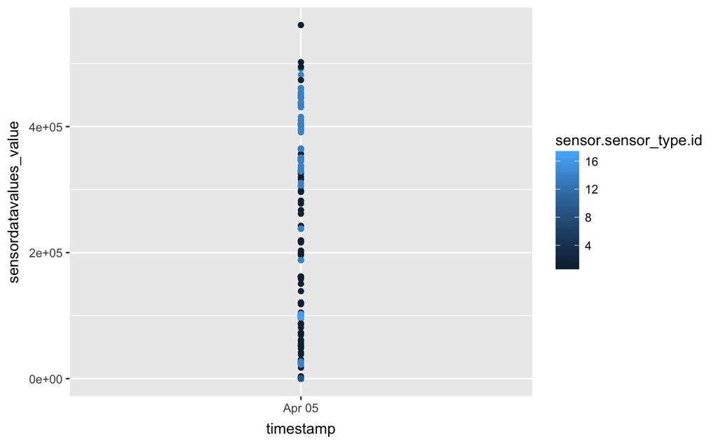

```r
Sensorwerte_numeric %>% ggplot + geom_point(aes(timestamp, sensordatavalues_value, color = sensor.sensor_type.id))
```

create list of sensor ids and how often they occur

```r
Sensorwerte_numeric %>% count(sensor.id) %>% arrange(desc(n))
```

| sensor.id | n |
| --- | --- |
| 156 | 81 |
| 89 | 48 |
| 603 | 45 |
| 81 | 42 |
| 106 | 30 |
| 107 | 30 |
| 305 | 30 |
| 556 | 30 |
| 618 | 30 |
| 140 | 25 |

[output cut: 958 more lines]

```r
Sensorwerte_numeric %>% count(location.id)  %>% arrange(desc(n))
```

| location.id | n |
| --- | --- |
| 70 | 81 |
| 49 | 60 |
| 43 | 56 |
| 289 | 53 |
| 65 | 50 |
| 148 | 50 |
| 228 | 50 |
| 256 | 50 |
| 47 | 48 |
| 264 | 42 |

[output cut: 493 more lines]

seems like there are more sensors on a given loction

```r
Sensorwerte_numeric %>% group_by(location.id, sensor.id) %>% summarise(n = n())-> Sensor_grouped
```

lets create a map with the sensors location  
leaflet did not work in the beginning, adding " html_document: default" in yaml header helped

map shows in editor and preview but at times not in browser

install devtools::install_github(“rstudio/leaflet”)

```r
Sensorwerte_numeric %>% distinct(location.longitude,location.latitude) -> Sensors_distinct_location
library(leaflet)
m <- leaflet() %>%
  addTiles() %>%  # Add default OpenStreetMap map tiles
  addMarkers(lng=Sensors_distinct_location$location.longitude, lat= Sensors_distinct_location$location.latitude, popup="Feinstaubsensor")
m  # Print the map
```

[interactive chart not shown]

ggmap seems the solution but get an error Error: GeomRasterAnn was built with an incompatible version of ggproto. Please reinstall the package that provides this extension. Console~/CloudProjectsUnderWork/ProjectsUnderWork/VhsDataVisualization/Rkenntnisse_2_2017/

then install devtools::install_github(“dkahle/ggmap”) based on http://stackoverflow.com/questions/40642850/ggmap-error-geomrasterann-was-built-with-an-incompatible-version-of-ggproto

solved the issue but then leaflet worked and is interactive and nicer…

[figure not shown]

```r
library(ggmap)
map <- get_map(location = 'Germany', zoom = 7)
ggmap(map)
```